# Imports and setup

#### Opening and pore fluid pressure profiles

```python
A_range = np.logspace(-2, 3, 6)
beta_cur = np.array([0.125])

sol_num = np.array([
    solve_tensile_prescribed_loading_impermeable_surfaces([beta_cur, A_cur], xi_range, xi_mid_range)[0] for A_cur in A_range
])
```

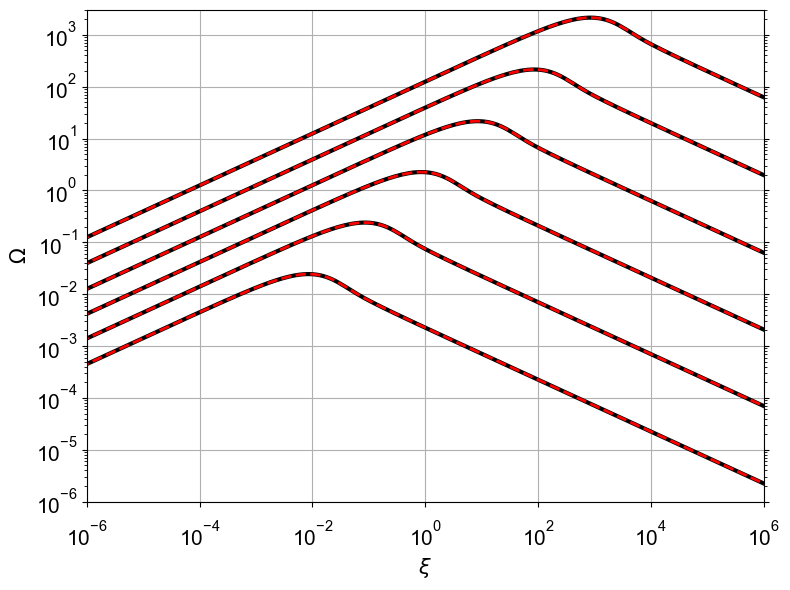

```python
plt.figure(figsize=(8,6))

for i in range(A_range.shape[0]):
    A_cur = A_range[i]

    plt.plot(xi_range, sol_num[i][:, 1], color='black', linestyle='-', linewidth=3)

    plt.plot(xi_range, K_analyt_func(beta_cur, A_cur) * A_cur ** 0.5 * dawsn((xi_range / A_cur) ** 0.5),
             color='red', linestyle='--', linewidth=2)

plt.xlim(1e-6, 1e6)
plt.ylim(1e-6, 3e3)

plt.xscale('log')
plt.yscale('log')

plt.xlabel(r'$\xi$', fontsize=15)
plt.ylabel(r'$\Omega$', fontsize=15)

plt.grid()

plt.show()
```

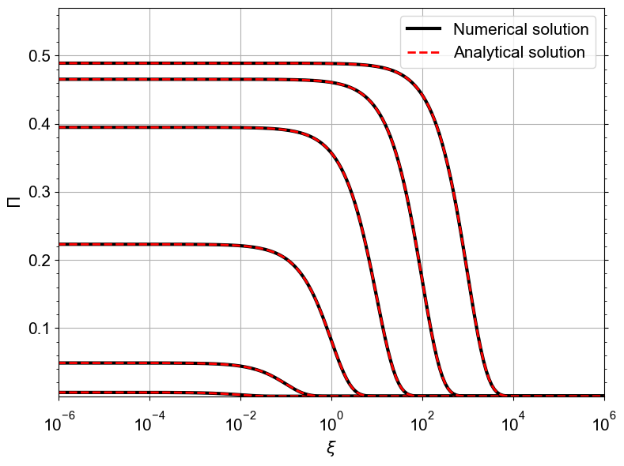

```python
plt.figure(figsize=(8,6))

eta_cur = 0.25
stor_cur = 2 * (1 - beta_cur) * eta_cur ** 2 / beta_cur

for i in range(A_range.shape[0]):
    A_cur = A_range[i]

    sol_cur = solve_tensile_prescribed_loading_impermeable_surfaces([beta_cur, A_cur], xi_range, xi_mid_range)

    plt.plot(xi_mid_range, -eta_cur / (2 * np.pi * stor_cur) * (sol_cur[1][1] @ sol_cur[-2]),
             color='black', linewidth=3)
    plt.plot(xi_mid_range, pres_coef_func(eta_cur, beta_cur, A_cur) * np.exp(-xi_mid_range/A_cur),
             color='red', linestyle='--', linewidth=2)

plt.plot([-1], [-1], color='black', linewidth=3, label='Numerical solution')
plt.plot([-1], [-1], linestyle='--', color='red', linewidth=2, label='Analytical solution')

plt.xlim(1e-6, 1e6)
plt.ylim(1e-6, 0.57)

plt.xscale('log')

plt.xlabel(r'$\xi$', fontsize=15)
plt.ylabel(r'$\Pi$', fontsize=15)

plt.legend(fontsize=15)

plt.grid()

plt.show()
```

#### Pore fluid pressure distribution

Pore fluid pressure distribution around the crack were precomputed separately in Wolfram Mathematica using numerical integration of the corresponding expressions. In this notebook, the precomputed CSV files are only loaded and plotted; the Mathematica integration is not recomputed here.

```python
pres_profile_num = np.loadtxt(data_folder / 'p_imperm_profiles.csv', delimiter=",")
pres_profile_semi_analyt = np.loadtxt(data_folder / 'p_imperm_profiles_ref.csv', delimiter=",")
```

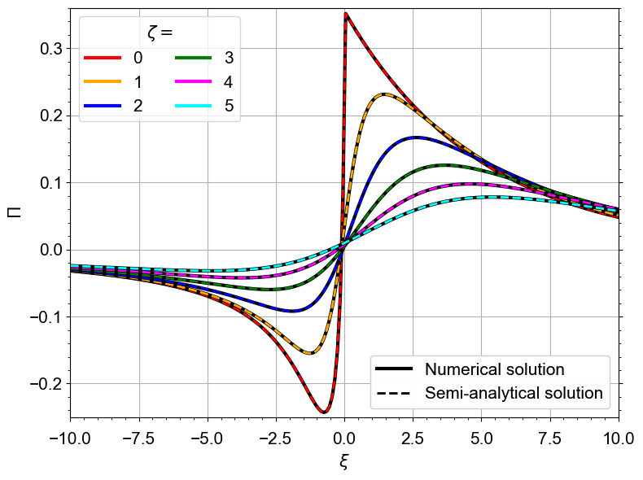

```python
xi_range = np.linspace(-10, 10, 202)

colors_list = ['red', 'orange', 'blue', 'green', 'magenta', 'cyan']

plt.figure(figsize=(8,6))

for i in range(pres_profile_num.shape[0]):
    plt.plot(xi_range, pres_profile_num[i, :], color='black', linewidth=3)
    plt.plot(xi_range, pres_profile_semi_analyt[i, :], linestyle='--', linewidth=2, color=colors_list[i])

    plt.plot([-100, -100], [-100, -100], linestyle='-', linewidth=3, label=f'{i}', color=colors_list[i])

plt.xlim(-10, 10)
plt.ylim(-0.25, 0.36)

plt.xlabel(r'$\xi$', fontsize=15)
plt.ylabel(r'$\Pi$', fontsize=15)

legend1 = plt.legend(fontsize=15, loc=2, title = r'$\zeta = $', title_fontsize=15, ncol=2)
plt.gca().add_artist(legend1)

line_1 = plt.Line2D([-1], [-1], color='black', linewidth=3, label='Numerical solution')
line_2 = plt.Line2D([-1], [-1], linestyle='--', color='black', linewidth=2, label='Semi-analytical solution')

legend2 = plt.legend(
    handles=[line_1, line_2],
    fontsize=15, loc=4,
)

plt.gca().add_artist(legend2)

plt.grid()

plt.show()
```

```python
pres_field_num = np.loadtxt(data_folder / "p_imperm_field.csv", delimiter=",")
```

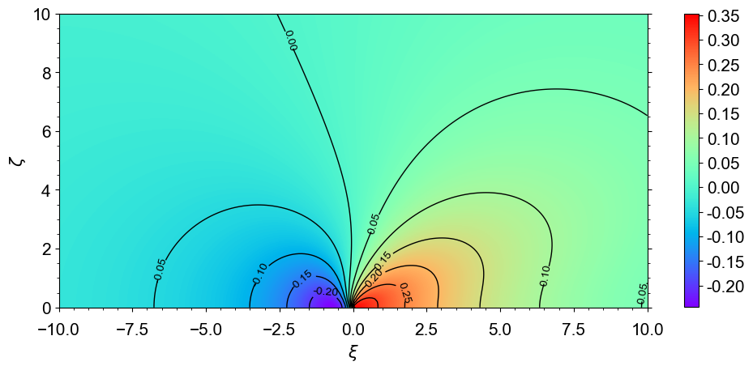

```python
x = np.linspace(-10, 10, 202)
y = np.linspace(0, 10, 101)

XX, YY = np.meshgrid(x, y)

fig, ax = plt.subplots(figsize=(10, 8))

CS = ax.contourf(XX, YY, pres_field_num, levels=1000, cmap='rainbow')

levels_ = np.concatenate((np.linspace(-0.25, 0.35, 13)[:5], np.array([0]), np.linspace(-0.25, 0.35, 13)[6:]))

CS_lines = ax.contour(XX, YY, pres_field_num, levels=levels_, colors='black', linewidths=1,linestyles='solid')

ax.clabel(CS_lines, inline=True, fontsize=10, fmt='%.2f')

cbar = fig.colorbar(CS, ax=ax, shrink=0.47, ticks=levels_)
cbar.ax.yaxis.set_major_formatter(FormatStrFormatter('%.2f'))

ax.set_xlabel(r'$\xi$', fontsize=15)
ax.set_ylabel(r'$\zeta$', fontsize=15)

ax.set_aspect('equal')

plt.show()
```

### Permeable fracture surfaces with prescribed zero pore fluid pressure (Section 7.1.2)

```python
num_points = 300

xi_range = np.logspace(-8, 10, num_points)
xi_mid_range = 0.5 * (xi_range[1:] + xi_range[:-1])

K_analyt_func = lambda beta, A: (8 * A ** (3/2) * (1 - beta)) / (np.pi ** 0.5 * (A + beta - (2 * A + 1) ** 0.5 * beta))
K_elastic_func = lambda A: 8 * (A / np.pi) ** 0.5

Y_coef = lambda eta, beta, A: (8 * A ** 0.5 * ((2 * A + 1) ** 0.5 - 1) * (beta - 1) * eta) / \
                                (np.pi ** 0.5 * (A + beta - (2 * A + 1) ** 0.5 * beta))
```

#### Dependence of $\mathcal{K}$ on $\beta$

```python
A_range = np.logspace(-2, 4, 7)
beta_range = np.linspace(0, 0.5, 100)
eta_cur = 0.25

K_num = [
    [solve_tensile_prescribed_loading_permeable_surfaces([eta_cur, beta_cur, A_cur], xi_range, xi_mid_range)[-1][0]
     for beta_cur in beta_range] for A_cur in A_range
]

K_analyt = [
    [K_analyt_func(beta_cur, A_cur) for beta_cur in beta_range] for A_cur in A_range
]

K_elastic = [
    K_elastic_func(A_cur) for A_cur in A_range
]
```

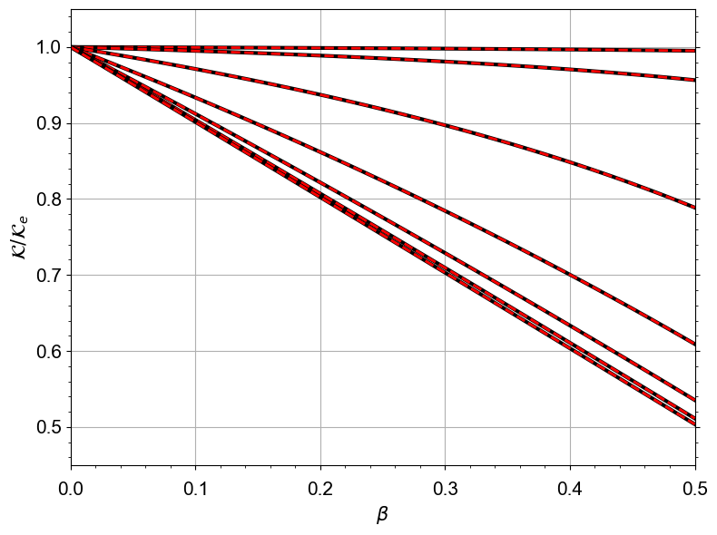

```python
plt.figure(figsize=(8, 6))

for i in range(A_range.shape[0]):
    plt.plot(beta_range, K_num[i] / K_elastic[i], color='black', linewidth=3)
    plt.plot(beta_range, K_analyt[i] / K_elastic[i], linestyle='--', color='red', linewidth=2)

plt.xlim(0, 0.5)
plt.ylim(0.45, 1.05)

plt.xlabel(r'$\beta$', fontsize=15)
plt.ylabel(r'$\mathcal{K}/\mathcal{K}_e$', fontsize=15)

plt.grid()

plt.show()
```

#### Dependence of $\mathcal{K}$ on $\mathcal{A}$

```python
A_range = np.logspace(-4, 5, 100)
beta_range = np.linspace(0, 0.5, 5)
eta_cur = 0.25

K_num = [
    [solve_tensile_prescribed_loading_permeable_surfaces([eta_cur, beta_cur, A_cur], xi_range, xi_mid_range)[-1][0]
     for A_cur in A_range] for beta_cur in beta_range
]

K_analyt = [
    [K_analyt_func(beta_cur, A_cur) for A_cur in A_range] for beta_cur in beta_range
]

K_elastic = K_elastic_func(A_range)
```

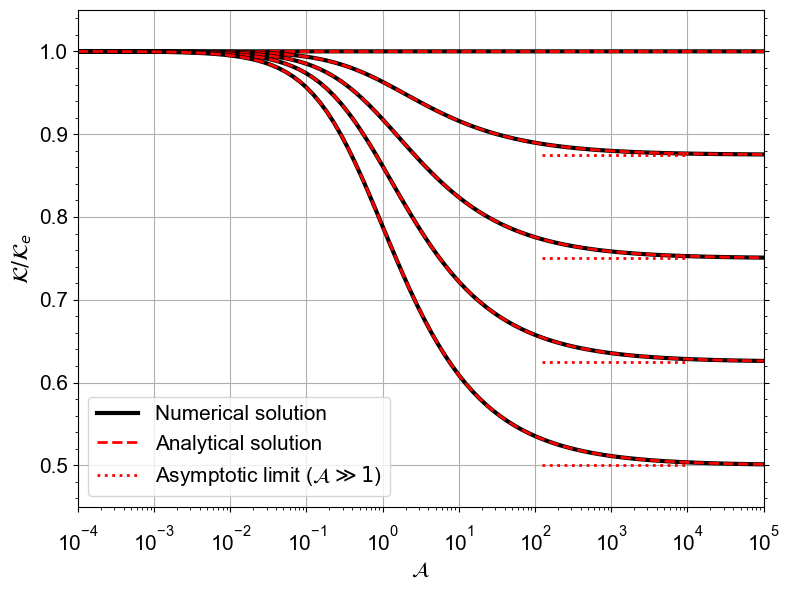

```python
plt.figure(figsize=(8, 6))

filter_ = np.logical_and(A_range > 1e2, A_range <= 1e4)

for i in range(beta_range.shape[0]):
    plt.plot(A_range, K_num[i] / K_elastic, color='black', linewidth=3)
    plt.plot(A_range, K_analyt[i] / K_elastic, linestyle='--', color='red', linewidth=2)
    plt.plot(A_range[filter_], np.ones_like(A_range[filter_]) * (1 - beta_range[i]),
             linestyle=':', color='red', linewidth=2)

plt.plot([-1], [-1], color='black', linewidth=3, label='Numerical solution')
plt.plot([-1], [-1], linestyle='--', color='red', linewidth=2, label='Analytical solution')
plt.plot([-1], [-1], linestyle=':', color='red', linewidth=2, label=r'Asymptotic limit ($\mathcal{A} \gg 1$)')

plt.xlim(1e-4, 1e5)
plt.ylim(0.45, 1.05)

plt.xscale('log')

plt.xlabel(r'$\mathcal{A}$', fontsize=15)
plt.ylabel(r'$\mathcal{K}/\mathcal{K}_e$', fontsize=15)

plt.legend(fontsize=15)

plt.grid()

plt.show()
```

#### Dependence of $\mathcal{K}$ on $\eta$

```python
A_range = np.logspace(-2, 5, 8)
beta_range = np.linspace(0.1, 0.5, 5)
eta_range = np.linspace(0.1, 0.5, 5)

rel_vals = []

for i in A_range:
    for j in beta_range:
        vals = np.array([solve_tensile_prescribed_loading_permeable_surfaces([k, j, i], xi_range, xi_mid_range)[-1][0]
                         for k in eta_range])
        rel_vals.append((vals.max() - vals.min()) / abs(vals.mean()))

print(np.max(np.abs(rel_vals)))
```

```
8.92918025739402e-15
```

#### Opening and fluid displacement function profiles

```python
A_range = np.logspace(-2, 4, 7)
beta_cur = 0.125
eta_cur = 0.25

sol_num = np.array([
    solve_tensile_prescribed_loading_permeable_surfaces([eta_cur, beta_cur, A_cur], xi_range, xi_mid_range)[0]
    for A_cur in A_range
])
```

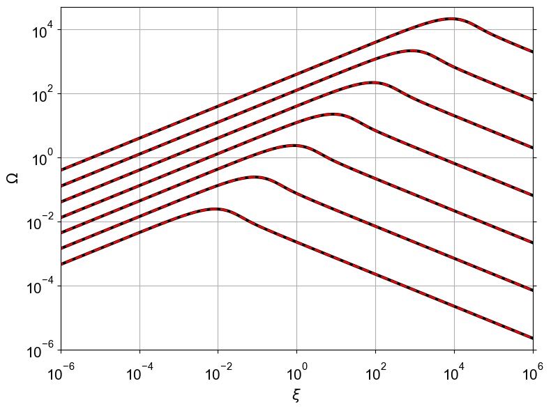

```python
plt.figure(figsize=(8,6))

for i in range(A_range.shape[0]):
    A_cur = A_range[i]
    plt.plot(xi_range, sol_num[i][:, 1], color='black', linewidth=3)
    plt.plot(xi_range, K_analyt_func(beta_cur, A_cur) * A_cur ** 0.5 * dawsn((xi_range / A_cur) ** 0.5),
             color='red', linestyle='--', linewidth=2)

plt.xlim(1e-6, 1e6)
plt.ylim(1e-6, 5e4)

plt.xscale('log')
plt.yscale('log')

plt.xlabel(r'$\xi$', fontsize=15)
plt.ylabel(r'$\Omega$', fontsize=15)

plt.grid()

plt.show()
```

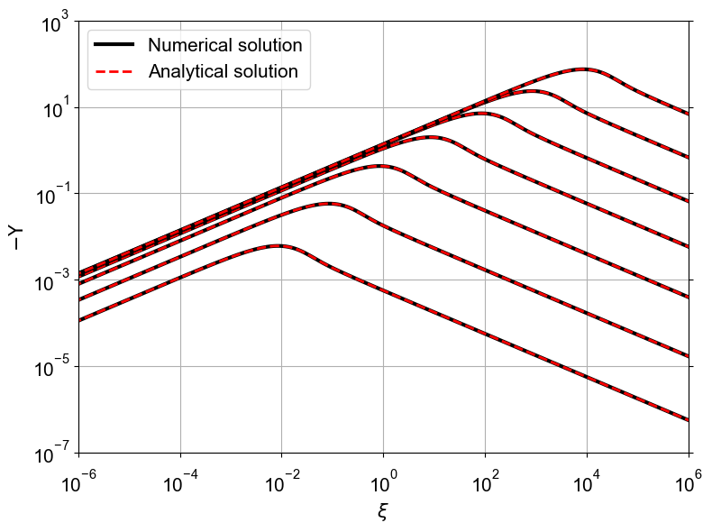

```python
plt.figure(figsize=(8,6))

for i in range(A_range.shape[0]):
    A_cur = A_range[i]
    plt.plot(xi_range, -(sol_num[i][:, 2]), linestyle='-', color='black', linewidth=3)
    plt.plot(xi_range, -Y_coef(eta_cur, beta_cur, A_cur) * A_cur ** 0.5 * dawsn((xi_range / A_cur) ** 0.5),
             color='red', linestyle='--', linewidth=2)

plt.plot([-1], [-1], color='black', linewidth=3, label='Numerical solution')
plt.plot([-1], [-1], color='red', linestyle='--', linewidth=2, label='Analytical solution')

plt.xlim(1e-6, 1e6)
plt.ylim(1e-7, 1e3)

plt.xscale('log')
plt.yscale('log')

plt.xlabel(r'$\xi$', fontsize=15)
plt.ylabel(r'$-\Upsilon$', fontsize=15)

plt.legend(fontsize=15)

plt.grid()

plt.show()
```

#### Pore fluid pressure distribution

Pore fluid pressure distribution around the crack were precomputed separately in Wolfram Mathematica using numerical integration of the corresponding expressions. In this notebook, the precomputed CSV files are only loaded and plotted; the Mathematica integration is not recomputed here.

```python
pres_profile_num = np.loadtxt(data_folder / "p_perm_profiles.csv", delimiter=",")
pres_profile_semi_analyt = np.loadtxt(data_folder / "p_perm_profiles_ref.csv", delimiter=",")
```

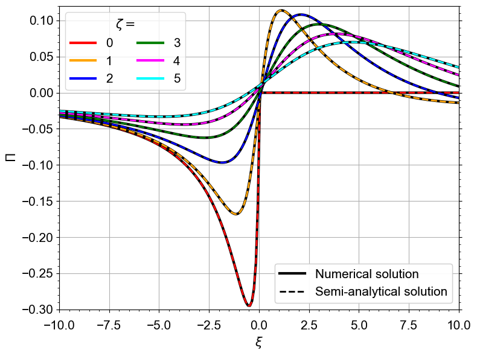

```python
xi_range = np.linspace(-10, 10, 202)

colors_list = ['red', 'orange', 'blue', 'green', 'magenta', 'cyan']

plt.figure(figsize=(8,6))

for i in range(pres_profile_num.shape[0]):
    plt.plot(xi_range, pres_profile_num[i, :], color='black', linewidth=3)
    plt.plot(xi_range, pres_profile_semi_analyt[i, :], color=colors_list[i], linestyle='--', linewidth=2)

    plt.plot([-100, -100], [-100, -100], linestyle='-', linewidth=3, label=f'{i}', color=colors_list[i])

plt.xlim(-10, 10)
plt.ylim(-0.3, 0.12)

plt.xlabel(r'$\xi$', fontsize=15)
plt.ylabel(r'$\Pi$', fontsize=15)

legend1 = plt.legend(fontsize=15, loc=2, title = r'$\zeta = $', title_fontsize=15, ncol=2)
plt.gca().add_artist(legend1)

line_1 = plt.Line2D([-1], [-1], color='black', linewidth=3, label='Numerical solution')
line_2 = plt.Line2D([-1], [-1], linestyle='--', color='black', linewidth=2, label='Semi-analytical solution')

legend2 = plt.legend(
    handles=[line_1, line_2],
    fontsize=15,
    loc=4
)

plt.gca().add_artist(legend2)

plt.grid()

plt.show()
```

```python
pres_field_num = np.loadtxt(data_folder / 'P_perm_field.csv', delimiter=",")
```

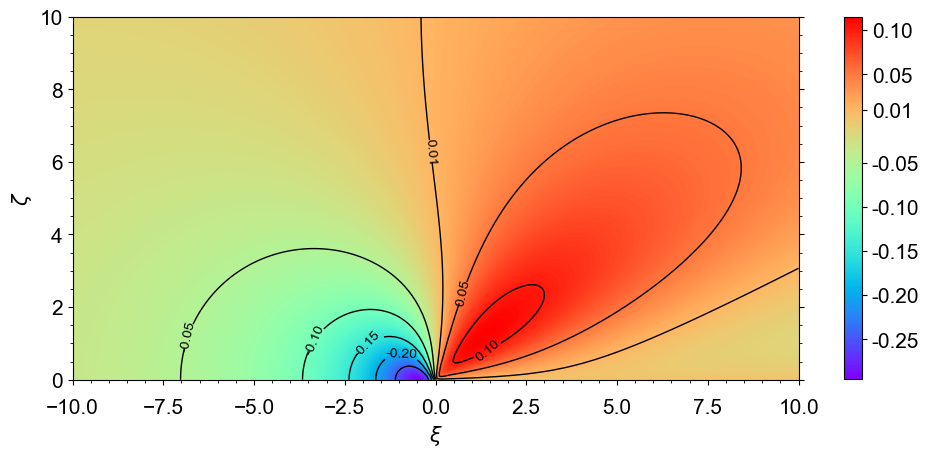

```python
x = np.linspace(-10, 10, 202)
y = np.linspace(0, 10, 101)

XX, YY = np.meshgrid(x, y)

fig, ax = plt.subplots(figsize=(10, 8))

CS = ax.contourf(XX, YY, pres_field_num, levels=1000, cmap='rainbow')

levels_ = np.concatenate((np.linspace(-0.3, 0.15, 10)[:6], np.array([1e-2]), np.linspace(-0.3, 0.15, 10)[7:]))

CS_lines = ax.contour(XX, YY, pres_field_num, levels=levels_, colors='black', linewidths=1,linestyles='solid')

ax.clabel(CS_lines, inline=True, fontsize=10, fmt='%.2f')

cbar = fig.colorbar(CS, ax=ax, shrink=0.47, ticks=levels_)
cbar.ax.yaxis.set_major_formatter(FormatStrFormatter('%.2f'))

ax.set_xlabel(r'$\xi$', fontsize=15)
ax.set_ylabel(r'$\zeta$', fontsize=15)

ax.set_aspect('equal')

plt.show()
```

#### Tensile stress profiles

```python
stress_profile_num = np.loadtxt(data_folder / "sigma_profiles.csv", delimiter=",")
stress_profile_analyt = np.loadtxt(data_folder / "sigma_profiles_ref.csv", delimiter=",")
```

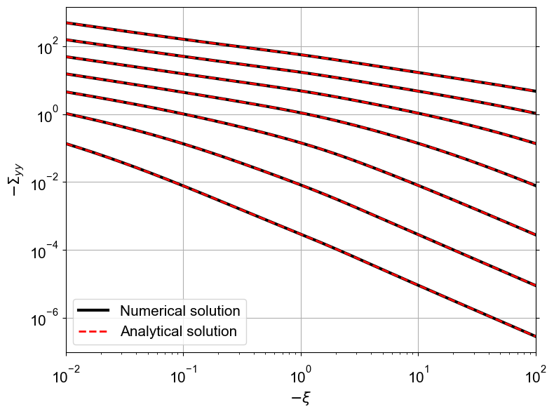

```python
xi_range = np.logspace(-2, 2, 201)

plt.figure(figsize=(8,6))

for i in range(stress_profile_num.shape[0]):
    plt.plot(xi_range, -stress_profile_num[i, :], color='black', linewidth=3)
    plt.plot(xi_range, -stress_profile_analyt[i, :], color='red', linestyle='--', linewidth=2)

plt.plot([-1], [-1], color='black', linewidth=3, label='Numerical solution')
plt.plot([-1], [-1], linestyle='--', color='red', linewidth=2, label='Analytical solution')

plt.xlim(1e-2, 1e2)

plt.xscale('log')
plt.yscale('log')

plt.xlabel(r'$-\xi$', fontsize=15)
plt.ylabel(r'$-\Sigma_{yy}$', fontsize=15)

plt.legend(fontsize=15, loc=3)

plt.grid()

plt.show()
```

## Stress-free semi-infinite tensile fracture with exponential pore pressure (Section 7.2)

```python
num_points = 300

xi_range = np.logspace(-8, 10, num_points)
xi_mid_range = 0.5 * (xi_range[1:] + xi_range[:-1])

K_analyt_func = lambda eta, beta, A: 2 * (4 * A ** (1/2) * ((2 * A + 1) ** 0.5 - 1) * (beta - 1) * eta) / \
                                        (np.pi ** 0.5 * (A + beta - (2 * A + 1) ** 0.5 * beta))

K_elastic_func = lambda A: 8 * (A / np.pi) ** 0.5

Y_coef = lambda eta, beta, A: (8 * (1 - beta) * ((2 * A + 1) ** 0.5 * (A - beta) + beta) * eta ** 2) / \
                                ((A * np.pi) ** 0.5 * beta * (A + beta - (2 * A + 1) ** 0.5 * beta))
```

### Dependence of $\mathcal{K}$ on $\beta$

```python
A_range = np.logspace(-2, 4, 7)
beta_range = np.concatenate((np.array([1e-3]), np.linspace(0, 0.5, 100)[1:]))
eta_cur = 0.25

K_num = np.array([
    [solve_tensile_prescribed_pore_pressure([eta_cur, beta_cur, A_cur], xi_range, xi_mid_range)[-1][0]
     for beta_cur in beta_range] for A_cur in A_range
])

K_analyt = np.array([
    [K_analyt_func(eta_cur, beta_cur, A_cur) for beta_cur in beta_range] for A_cur in A_range
])
```

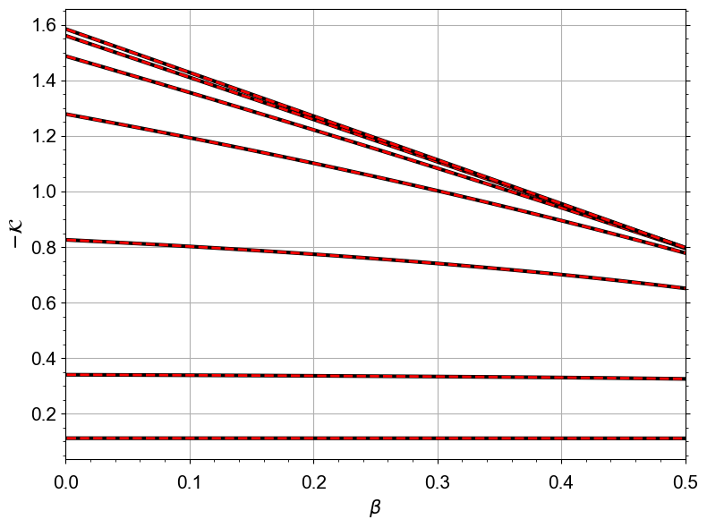

```python
plt.figure(figsize=(8, 6))

for i in range(A_range.shape[0]):
    plt.plot(beta_range, -K_num[i], color='black', linewidth=3)
    plt.plot(beta_range, -K_analyt[i], linestyle='--', color='red', linewidth=2)

plt.xlim(0, 0.5)

plt.xlabel(r'$\beta$', fontsize=15)
plt.ylabel(r'$-\mathcal{K}$', fontsize=15)

plt.grid()

plt.show()
```

### Dependence of $\mathcal{K}$ on $\mathcal{A}$

```python
A_range = np.logspace(-4, 5, 100)
beta_range = np.concatenate((np.array([1e-3]), np.linspace(0.125, 0.5, 4)))
eta_cur = 0.25

K_num = np.array([
    [solve_tensile_prescribed_pore_pressure([eta_cur, beta_cur, A_cur], xi_range, xi_mid_range)[-1][0] \
     for A_cur in A_range] for beta_cur in beta_range
])

K_analyt = np.array([
    [K_analyt_func(eta_cur, beta_cur, A_cur) for A_cur in A_range] for beta_cur in beta_range
])
```

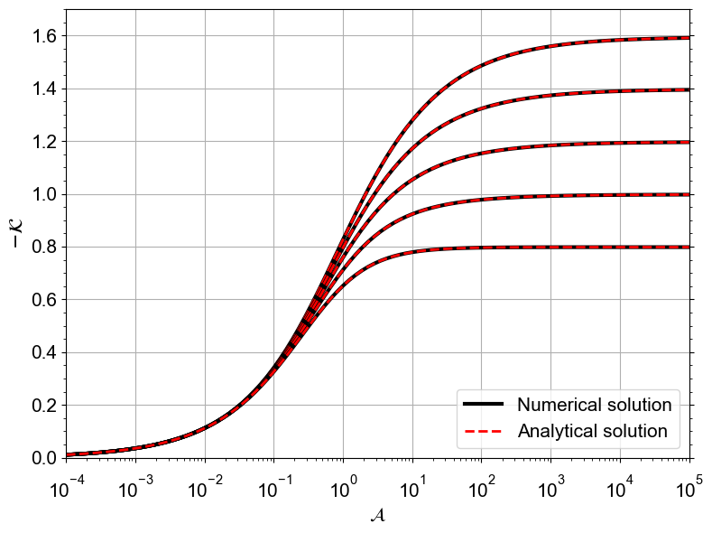

```python
plt.figure(figsize=(8, 6))

for i in range(beta_range.shape[0]):
    plt.plot(A_range, -K_num[i], color='black', linewidth=3)
    plt.plot(A_range, -K_analyt[i], linestyle='--', color='red', linewidth=2)

plt.plot([-1], [-1], color='black', linewidth=3, label='Numerical solution')
plt.plot([-1], [-1], linestyle='--', color='red', linewidth=2, label='Analytical solution')

plt.xlim(1e-4, 1e5)
plt.ylim(0., 1.7)

plt.xscale('log')

plt.xlabel(r'$\mathcal{A}$', fontsize=15)
plt.ylabel(r'$-\mathcal{K}$', fontsize=15)

plt.legend(fontsize=15, loc=4)

plt.grid()

plt.show()
```

### Dependence of $\mathcal{K}$ on $\eta$

```python
A_range = np.logspace(-2, 4, 7)
eta_range = np.concatenate((np.array([1e-3]), np.linspace(0, 0.5, 100)[1:]))
beta_cur = 0.125

K_num = np.array([
    [solve_tensile_prescribed_pore_pressure([eta_cur, beta_cur, A_cur], xi_range, xi_mid_range)[-1][0]
     for eta_cur in eta_range] for A_cur in A_range
])

K_analyt = np.array([
    [K_analyt_func(eta_cur, beta_cur, A_cur) for eta_cur in eta_range] for A_cur in A_range
])
```

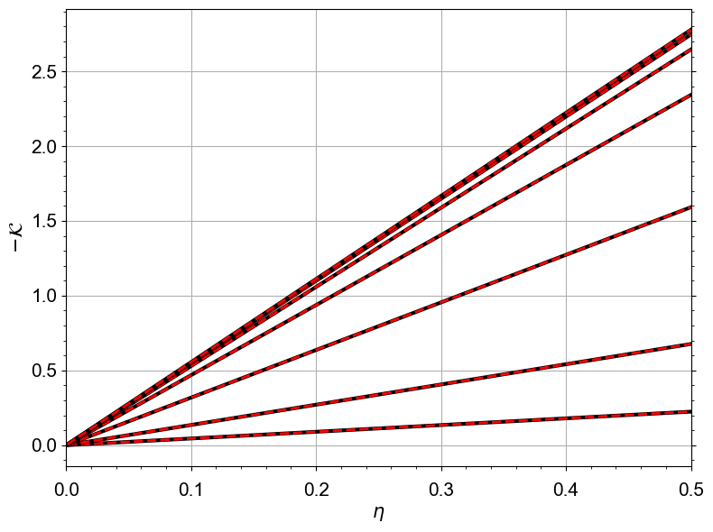

```python
plt.figure(figsize=(8, 6))

for i in range(A_range.shape[0]):
    plt.plot(eta_range, -K_num[i], color='black', linewidth=3)
    plt.plot(eta_range, -K_analyt[i], linestyle='--', color='red', linewidth=2)

plt.xlim(0, 0.5)

plt.xlabel(r'$\eta$', fontsize=15)
plt.ylabel(r'$-\mathcal{K}$', fontsize=15)

plt.grid()

plt.show()
```

### Opening and fluid displacement function profiles

```python
A_range = np.logspace(-2, 4, 7)
beta_cur = 0.125
eta_cur = 0.25

sol_num = np.array([
    solve_tensile_prescribed_pore_pressure([eta_cur, beta_cur, A_cur], xi_range, xi_mid_range)[0] for A_cur in A_range
])
```

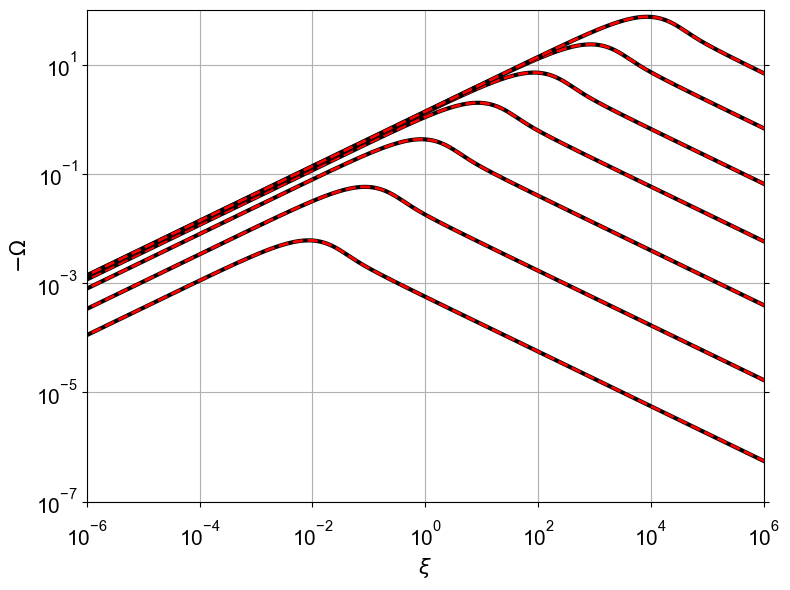

```python
plt.figure(figsize=(8,6))

for i in range(A_range.shape[0]):
    A_cur = A_range[i]
    plt.plot(xi_range, -sol_num[i][:, 1], color='black', linewidth=3)
    plt.plot(xi_range, -K_analyt_func(eta_cur, beta_cur, A_cur) * A_cur ** 0.5 * dawsn((xi_range / A_cur) ** 0.5),
             linestyle='--', color='red', linewidth=2)

plt.xlim(1e-6, 1e6)
plt.ylim(1e-7, 1e2)

plt.xscale('log')
plt.yscale('log')

plt.xlabel(r'$\xi$', fontsize=15)
plt.ylabel(r'$-\Omega$', fontsize=15)

plt.grid()

plt.show()
```

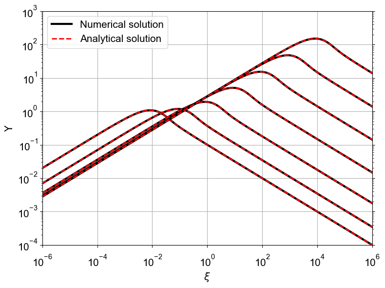

```python
plt.figure(figsize=(8,6))

for i in range(A_range.shape[0]):
    A_cur = A_range[i]
    plt.plot(xi_range, sol_num[i][:, 2], color='black', linewidth=3)
    plt.plot(xi_range, Y_coef(eta_cur, beta_cur, A_cur) * A_cur ** 0.5 * dawsn((xi_range / A_cur) ** 0.5),
             linestyle='--', color='red', linewidth=2)

plt.plot([-1], [-1], color='black', linewidth=3, label='Numerical solution')
plt.plot([-1], [-1], linestyle='--', color='red', linewidth=2, label='Analytical solution')

plt.xlim(1e-6, 1e6)
plt.ylim(1e-4, 1e3)

plt.xscale('log')
plt.yscale('log')

plt.xlabel(r'$\xi$', fontsize=15)
plt.ylabel(r'$\Upsilon$', fontsize=15)

plt.legend(fontsize=15)

plt.grid()

plt.show()
```

## Semi-infinite shear fracture under constant loading along a strip (Section 7.3)

```python
num_points = 300

xi_range = np.logspace(-8, 10, num_points)
xi_mid_range = 0.5 * (xi_range[1:] + xi_range[:-1])

K_elastic_func = lambda A: 16 * A ** 0.5 / np.pi

def slip_profile_elastic(x, A, K):
    x = np.asarray(x, dtype=float)

    val = 4 / np.pi * (2 * (x * A) ** 0.5 + (A - x) * np.log(np.abs((x ** 0.5 + A ** 0.5) / (x ** 0.5 - A ** 0.5))))

    val[x == A] = 8 * A / np.pi

    return K * val
```

The analytical $\mathcal{K}$ values were precomputed in Wolfram Mathematica using complex variable expressions and are loaded here from a CSV file.

### Dependence of $\mathcal{K}$ on $\beta$

```python
A_range_vals = np.logspace(-2, 4, 7)
A_range = np.array([xi_range[np.argmin(np.abs(xi_range - A_cur))] for A_cur in A_range_vals])
beta_range = np.linspace(0, 0.5, 100)

K_num = [
    [solve_shear_prescribed_loading([beta_cur, A_cur], xi_range, xi_mid_range)[-1]
     for beta_cur in beta_range] for A_cur in A_range
]

K_analyt = np.loadtxt(data_folder / "rice_simons_beta_variation.csv", delimiter=",")
```

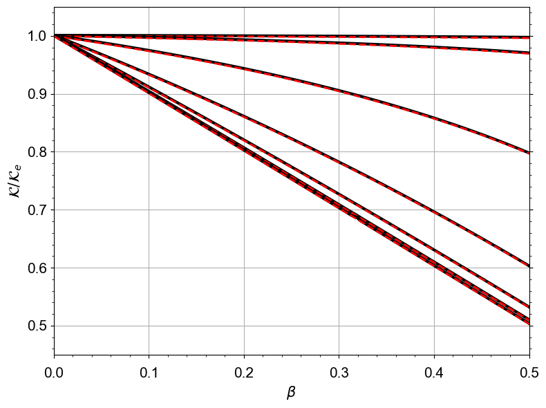

```python
plt.figure(figsize=(8, 6))

for i in range(A_range.shape[0]):
    plt.plot(beta_range, K_num[i] / K_elastic_func(A_range[i]), color='black', linewidth=3)
    plt.plot(beta_range, K_analyt[:, i], linestyle='--', color='red', linewidth=2)

plt.xlim(0, 0.5)
plt.ylim(0.45, 1.05)

plt.xlabel(r'$\beta$', fontsize=15)
plt.ylabel(r'$\mathcal{K}/\mathcal{K}_e$', fontsize=15)

plt.grid()

plt.show()
```

### Dependence of $\mathcal{K}$ on $\mathcal{A}$

```python
A_range = xi_range[np.logical_and(xi_range > 1e-4, xi_range < 1e5)]
beta_range = np.linspace(0, 0.5, 5)

K_num = [
    [solve_shear_prescribed_loading([beta_cur, A_cur], xi_range, xi_mid_range)[-1]
     for A_cur in A_range] for beta_cur in beta_range
]

K_analyt = np.loadtxt(data_folder / "rice_simons_a_variation.csv", delimiter=",")
```

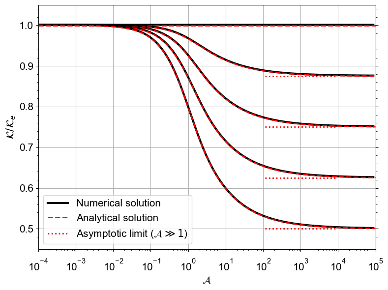

```python
plt.figure(figsize=(8, 6))

filter_ = np.logical_and(A_range > 1e2, A_range <= 1e4)

for i in range(beta_range.shape[0]):
    plt.plot(A_range, K_num[i] / K_elastic_func(A_range), color='black', linewidth=3)
    plt.plot(np.logspace(-4, 5, 500), K_analyt[i], color='red', linestyle='--', linewidth=2)

    if i > 0:
        plt.plot(A_range[filter_], np.ones_like(A_range[filter_]) * (1 - beta_range[i]),
                 linestyle=':', color='red', linewidth=2)

plt.plot([-1], [-1], color='black', linewidth=3, label='Numerical solution')
plt.plot([-1], [-1], linestyle='--', color='red', linewidth=2, label='Analytical solution')
plt.plot([-1], [-1], linestyle=':', color='red', linewidth=2, label=r'Asymptotic limit ($\mathcal{A} \gg 1$)')

plt.xlim(1e-4, 1e5)
plt.ylim(0.45, 1.05)

plt.xscale('log')

plt.grid(True)
plt.xlabel(r'$\mathcal{A}$', fontsize=15)
plt.ylabel(r'$\mathcal{K}/\mathcal{K}_e$', fontsize=15)

plt.legend(fontsize=15)

plt.show()
```

### Slip profiles

```python
A_range_vals = np.logspace(-2, 4, 7)
A_range = np.array([xi_range[np.argmin(np.abs(xi_range - A_cur))] for A_cur in A_range_vals])
beta_cur = np.array([0.125])

sol_num = np.array([solve_shear_prescribed_loading([beta_cur, A_cur], xi_range, xi_mid_range)[0] for A_cur in A_range])

beta_range = np.linspace(0, 0.5, 100)
K_analyt = np.loadtxt(data_folder / "rice_simons_beta_variation.csv", delimiter=",")
```

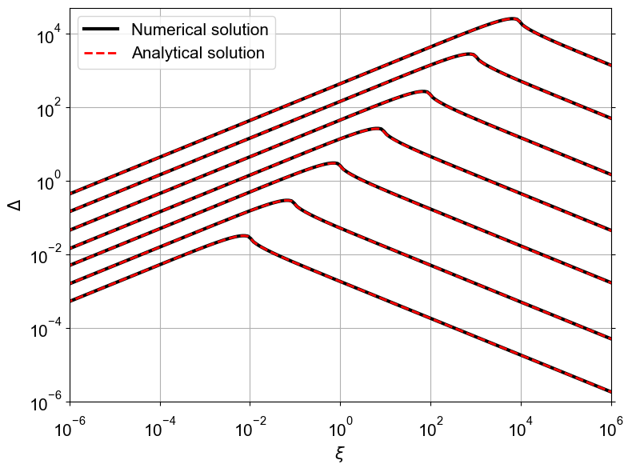

```python
plt.figure(figsize=(8,6))

for i in range(A_range.shape[0]):
    plt.plot(xi_range, sol_num[i][:, 1], color='black', linewidth=3)

    interp_vals = interp1d(beta_range, K_analyt[:, i], kind='cubic')(0.125)
    plt.plot(xi_range, slip_profile_elastic(xi_range, A_range[i], interp_vals), linestyle='--', color='red', linewidth=2)

plt.plot([-1], [-1], color='black', linewidth=3, label='Numerical solution')
plt.plot([-1], [-1], linestyle='--', color='red', linewidth=2, label='Analytical solution')

plt.xlim(1e-6, 1e6)
plt.ylim(1e-6, 5e4)

plt.xscale('log')
plt.yscale('log')

plt.xlabel(r'$\xi$', fontsize=15)
plt.ylabel(r'$\Delta$', fontsize=15)

plt.legend(fontsize=15)

plt.grid()

plt.show()
```